# SN-Project-B-Group-3

Group 3

March 9, 2019

## Introduction & Conclusion

Group 3 - Jamie Pan; Jiaying Liu; Haolin Yang; Lingchen Kong

### Workflow and Approach

For this project B, we conduct our analysis approaches and models with the following workflows:

- General descriptions for dataset and analytic questions;
- Desrptive analysis at both network level and node level;
- Subgroup and role analysis;
- Statistical analysis including QAP, ERGM, and TERGM.

### General dscription & Modification to dataset

We have two network dataset (‘often’ and ‘trust’) and one attribute dataset (‘att’) for each of the 2015 and 2016 dataset file.

In the attribute dataset, the categorical variable (‘workgroup’, ‘attendees’, ‘sex’, ‘race’) gives out the attribute information about the network member. The rest of variables in the table such as ‘cancer’ are bianry variables, where ‘1’ indicates ‘yes’ and ‘0’ for answering ‘no’.

The ‘trust’ network dataset gives the trust level of network members on each other, and ‘often’ network dataset give the level of often contact for network members with each other. Both networks are directed and weightes with higher number indicating higher level.

However, when we compare the ‘trust’ and ‘often’ datasets for 2015 and 2016, we found taht the network members contained in datasets of different years are not the same. In order to smoothly conduct the TERGM model as test on the network changes through time, we paddled these datasets in two years. So for both data, we contain the orginical data and add the missing network member from another dataset into this one, with the edge value set at 0 by default. The new datasets are named as ‘trust11’ and ‘often11’. Also, before paddling, we had a basic clean up and rename for better understandale variables for the original dataset as well. The re-organized dataset are named as ‘trust1’ and ‘often1’, which are the paddled dataset based on.

### Conclusion & Major Findings

Based on our teamwork of model approahces and analysis, we had a deeper look of the often-contact and trust networks, and the following are our major findings:

- There are two important network member, VT8 and VT9. They occurs in both 2015 and 2016 networks, and both of them have extremely high betweenness centrality in both trust and often-contact networks, in both 2015 and 2016. Thus, we can assume that VT8 AND VT9 are acting important roles of imformation transportation and network bridges in this group.
- The mean distance for trust network is generally lower than it for often-contact network, and the global clustering coefficient for trust nework is generally higher than it for often-contact network. These two findings match with common sense that information transformationa and networking activities is usually faster between trusted people.
- By community detection, we found that people whitn the same trust communities are more likely to contact each other.
- By QAP modeling on trust and often-contact networks in 2015 and 2016, we conclude that two networks have strong and siginificant predictive power on each other. This helps to explain the common sense that people are more willing to contact with the person they are trusted with, as well as people are more like to build up trustness by the accumulation of the communications.
- From the ERGM test, we notice that none of the attributes of network members has significantly strong effects on forming trust ties or often-contact ties. But, the transitivies became an important effect on both networks. Thus, we can conclude that people would not choose to trust or contact with others by their individual background, and it’s easier to build trustness on trusted frineds’ trust and to be closer friends on frinds’ close friends.
- By TERGM modeling on each of the trust and often-contact networks, we can conclude that both trust and often-contact networks would have much higher probablity of tie occurring with the presense of mutual ties and transitivities, while the trust network contains effect of Attendees attribute with time sliding fron 2015 to 2016.

## Library and Data Preparation

```r
# load library
library(readxl)
library(igraph)
library(intergraph)
library(sna)
library(ergm)
library(tergm)
library(statnet)
library(ndtv)
library(htmlwidgets)
library(latticeExtra)
# The xlsx file with '11' suffix is paddled into a the same size for the tergm analysis
rm(list=ls())
trust2015 <- as.data.frame(read_excel("2015/trust11.xlsx"))
trust2016 <- as.data.frame(read_excel("2016/trust11.xlsx"))
often2015 <- as.data.frame(read_excel("2015/often11.xlsx"))
often2016 <- as.data.frame(read_excel("2016/often11.xlsx"))
att2015<- as.data.frame(read_excel("2015/att.xlsx"))
att2016<- as.data.frame(read_excel("2016/att.xlsx"))

trust2015 [is.na(trust2015 )] <- 0
trust2016 [is.na(trust2016 )] <- 0
often2015 [is.na(often2015 )] <- 0
often2016 [is.na(often2016 )] <- 0
att2015[is.na(att2015 )] <- 0
att2016[is.na(att2016 )] <- 0

of2015 <- data.matrix(often2015[,-1])
of2016 <- data.matrix(often2016[,-1])
tru2015 <- data.matrix(trust2015[,-1])
tru2016 <- data.matrix(trust2016[,-1])

rownames(of2015) <- colnames(often2015)[-1]
rownames(of2016) <- colnames(often2016)[-1]
rownames(tru2015) <- colnames(trust2015)[-1]
rownames(tru2016) <- colnames(trust2016)[-1]

z=2
of2015 <- ifelse(of2015 > z, 1, 0)
diag(of2015) <- 0
of2016 <- ifelse(of2016 > z, 1, 0)
diag(of2015) <- 0
tru2015 <- ifelse(tru2015 > z, 1, 0)
diag(tru2015) <- 0
tru2016 <- ifelse(tru2016 > z, 1, 0)
diag(tru2016) <- 0

of2015 <- graph.adjacency(of2015)
of2016 <- graph.adjacency(of2016)
tru2015 <- graph.adjacency(tru2015)
tru2016 <- graph.adjacency(tru2016)

for(cn in colnames(att2015)[-1]) {
     of2015 <- set_vertex_attr(of2015, cn, 1:nrow(att2015), value = att2015[,cn])
     tru2015 <- set_vertex_attr(tru2015, cn, 1:nrow(att2015), value = att2015[,cn])

}
for(cn in colnames(att2016)[-1]) {
     of2016 <- set_vertex_attr(of2016, cn, 1:nrow(att2016), value = att2016[,cn])
     tru2016 <- set_vertex_attr(tru2016, cn, 1:nrow(att2016), value = att2016[,cn])
}
```

```r
# The xlsx file with '1' suffix is the original dataset
trustt2015 <- as.data.frame(read_excel("2015/trust1.xlsx"))
trustt2016 <- as.data.frame(read_excel("2016/trust1.xlsx"))
oftenn2015 <- as.data.frame(read_excel("2015/often1.xlsx"))
oftenn2016 <- as.data.frame(read_excel("2016/often1.xlsx"))

trustt2015 [is.na(trustt2015 )] <- 0
trustt2016 [is.na(trustt2016 )] <- 0
oftenn2015 [is.na(oftenn2015 )] <- 0
oftenn2016 [is.na(oftenn2016 )] <- 0

off2015 <- data.matrix(oftenn2015[,-1])
off2016 <- data.matrix(oftenn2016[,-1])
truu2015 <- data.matrix(trustt2015[,-1])
truu2016 <- data.matrix(trustt2016[,-1])

rownames(off2015) <- colnames(oftenn2015)[-1]
rownames(off2016) <- colnames(oftenn2016)[-1]
rownames(truu2015) <- colnames(trustt2015)[-1]
rownames(truu2016) <- colnames(trustt2016)[-1]

off2015 <- ifelse(off2015 > z, 1, 0)
diag(off2015) <- 0
off2016 <- ifelse(off2016 > z, 1, 0)
diag(off2015) <- 0
truu2015 <- ifelse(truu2015 > z, 1, 0)
diag(truu2015) <- 0
truu2016 <- ifelse(truu2016 > z, 1, 0)
diag(truu2016) <- 0

off2015 <- graph.adjacency(off2015)
off2016 <- graph.adjacency(off2016)
truu2015 <- graph.adjacency(truu2015)
truu2016 <- graph.adjacency(truu2016)

for(cn in colnames(att2015)[-1]) {
     off2015 <- set_vertex_attr(off2015, cn, 1:nrow(att2015), value = att2015[,cn])
     truu2015 <- set_vertex_attr(truu2015, cn, 1:nrow(att2015), value = att2015[,cn])

}
for(cn in colnames(att2016)[-1]) {
     off2016 <- set_vertex_attr(off2016, cn, 1:nrow(att2016), value = att2016[,cn])
     truu2016 <- set_vertex_attr(truu2016, cn, 1:nrow(att2016), value = att2016[,cn])
}
```

## Descriptive Analysis

These two datasets have little differences in basic parameters, since the paddling only adds dummy edge value of 0, which would not bias analysis results. Thus, for network level analysis, we conduct the analysis on the paddled dataset only to save time and repeated work and unite the network member. For node level analysis, we conduct the analysis on the un-paddeled dataset only, since the extra members from another year would only show isolates and no edge values at all.

### Descriptive Analysis on paddled ‘often - 2015’ network

```r
#Basic parameters
#Vertex
vcount(of2015)
```

```
## [1] 49
```

```r
#Edge
ecount(of2015)
```

```
## [1] 51
```

```r
#Density
edge_density(of2015)
```

```
## [1] 0.02168367
```

```r
#Shortest Path
mean_distance(of2015, directed = TRUE)
```

```
## [1] 3.134783
```

```r
#Diameter
diameter(of2015)
```

```
## [1] 9
```

```r
#In-degree part
indegree_of2015 <- igraph::degree(of2015, mode = "in")
#Mean
mean(indegree_of2015)
```

```
## [1] 1.040816
```

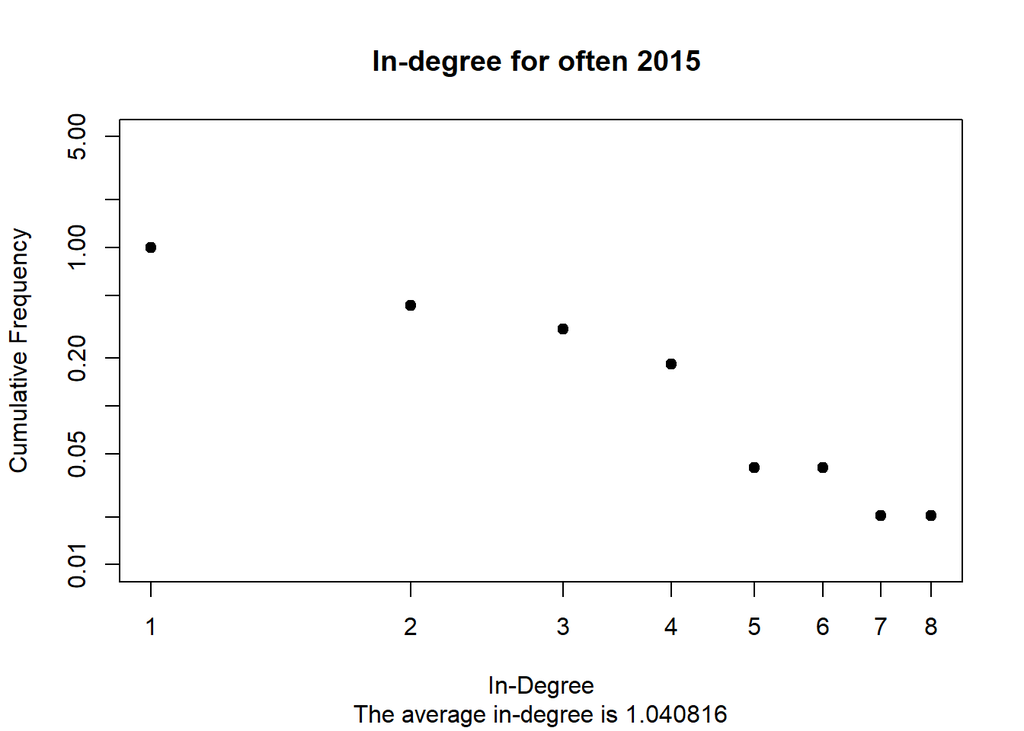

```r
indegree_dist_of2015 <- igraph::degree.distribution(of2015, mode = "in", cumulative = FALSE)
indegree_cdist_of2015 <- igraph::degree.distribution(of2015, mode = "in", cumulative = TRUE)
plot(indegree_cdist_of2015, log = "xy", ylim = c(.01, 5), bg = "black", pch = 21,
     xlab = "In-Degree", ylab = "Cumulative Frequency")
title("In-degree for often 2015 ", sub = "The average in-degree is 1.040816")
```

```r
#Out-degree
outdegree_of2015 <- igraph::degree(of2015, mode = "out")
#Mean
mean(outdegree_of2015)
```

```
## [1] 1.040816
```

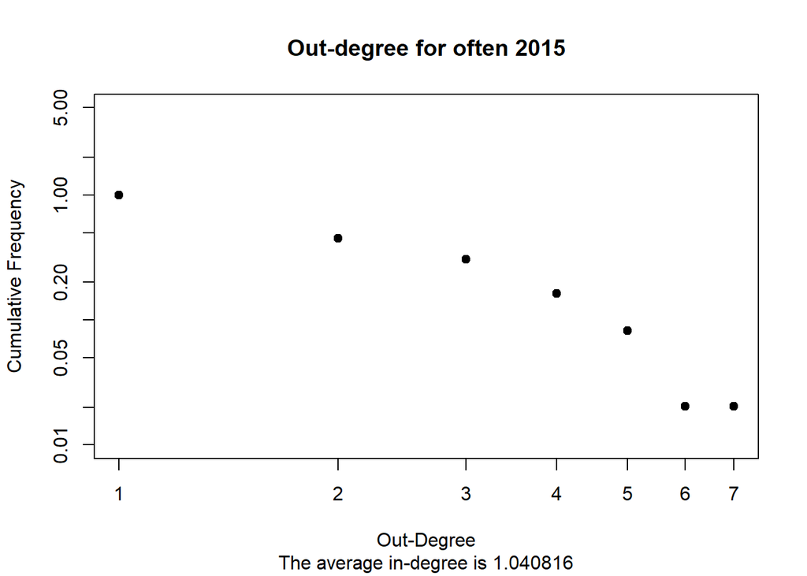

```r
outdegree_dist_of2015 <- igraph::degree.distribution(of2015, mode = "out", cumulative = FALSE)
outdegree_cdist_of2015 <- igraph::degree.distribution(of2015, mode = "out", cumulative = TRUE)
plot(outdegree_cdist_of2015, log = "xy", ylim = c(.01, 5), bg = "black", pch = 21,xlab ="Out-Degree",ylab = "Cumulative Frequency")
title("Out-degree for often 2015", sub = "The average in-degree is 1.040816")
```

```r
#transitivity
#Local
localCC_of2015 <- transitivity(of2015, type = "local")
localCC_df_of2015 <- data.frame(Name = V(of2015)$name, localCC_of2015)
localCC_df_of2015 <- localCC_df_of2015[order(localCC_df_of2015$localCC_of2015, decreasing = TRUE),]
head(localCC_df_of2015, 6)
```

```
##    Name localCC_of2015
## 1   VT1      0.6666667
## 24 VT24      0.5000000
## 17 VT17      0.3000000
## 19 VT19      0.2857143
## 3   VT3      0.2380952
## 16 VT16      0.2000000
```

```r
#Global
globalCC_of2015 <- transitivity(of2015)
globalCC_of2015
```

```
## [1] 0.2970297
```

Basic Parameters for dataset paddled ‘often - 2015’:

- Number of Vertex: 49
- Number of Edge: 51
- Edge Density: 0.02168367
- Mean Shortest Path Length: 3.134783
- Network Diameter: 9
- Average in-degree: 1.040816
- Average out-degree: 1.040816
- Global Clustering Coeffient: 0.2970297

(Findings at next section)

### Descriptive Analysis of paddled ‘trust - 2015’ network

```r
#Vertex
vcount(tru2015)
```

```
## [1] 49
```

```r
#Edge
ecount(tru2015)
```

```
## [1] 100
```

```r
#Density
edge_density(tru2015)
```

```
## [1] 0.04251701
```

```r
#Shortest Path
mean_distance(tru2015)
```

```
## [1] 2.524561
```

```r
#Diameter
diameter(tru2015)
```

```
## [1] 5
```

```r
#In-degree part
indegree_tru2015 <- igraph::degree(tru2015, mode = "in")
#Mean
mean(indegree_tru2015)
```

```
## [1] 2.040816
```

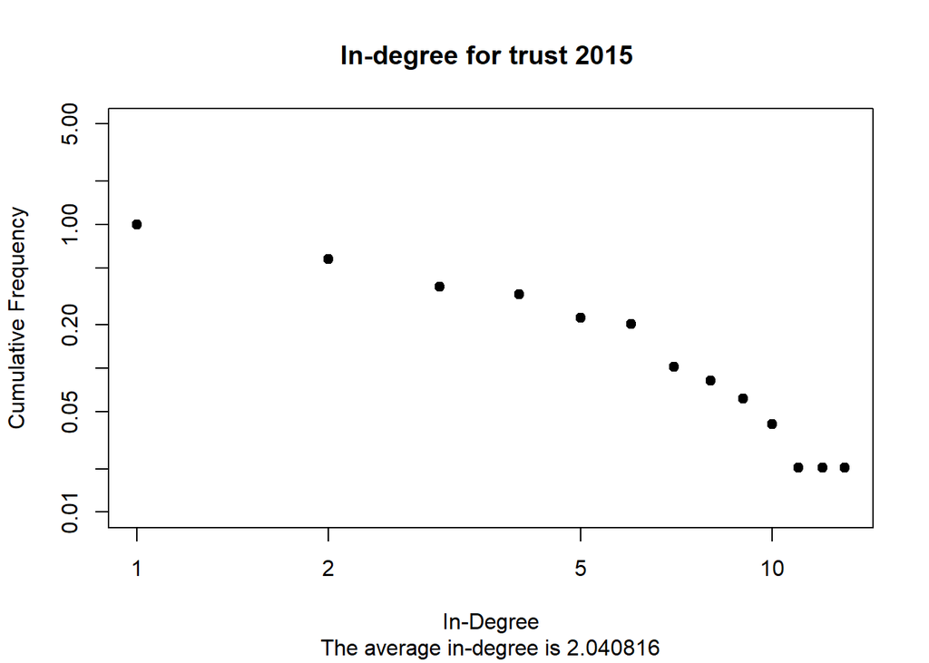

```r
indegree_dist_tru2015 <- igraph::degree.distribution(tru2015, mode = "in", cumulative = FALSE)
indegree_cdist_tru2015 <- igraph::degree.distribution(tru2015, mode = "in", cumulative = TRUE)
plot(indegree_cdist_tru2015, log = "xy", ylim = c(.01, 5), bg = "black", pch = 21,
     xlab = "In-Degree", ylab = "Cumulative Frequency")
title("In-degree for trust 2015 ", sub = "The average in-degree is 2.040816")
```

```r
#Out-degree
outdegree_tru2015 <- igraph::degree(tru2015, mode = "out")
#Mean
mean(outdegree_tru2015)
```

```
## [1] 2.040816
```

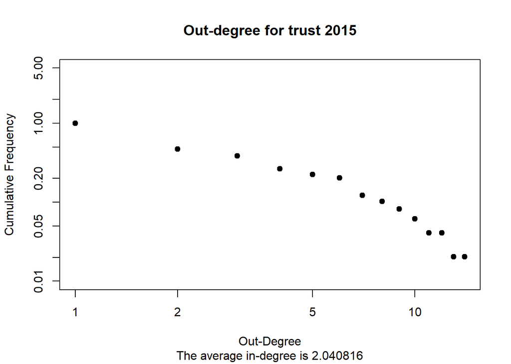

```r
outdegree_dist_tru2015 <- igraph::degree.distribution(tru2015, mode = "out", cumulative = FALSE)
outdegree_cdist_tru2015 <- igraph::degree.distribution(tru2015, mode = "out", cumulative = TRUE)
plot(outdegree_cdist_tru2015, log = "xy", ylim = c(.01, 5), bg = "black", pch = 21,xlab ="Out-Degree",ylab = "Cumulative Frequency")
title("Out-degree for trust 2015", sub = "The average in-degree is 2.040816")
```

```r
#Transitivity
#Local
localCC_tru2015 <- transitivity(tru2015, type = "local")
localCC_df_tru2015 <- data.frame(Name = V(tru2015)$name, localCC_tru2015)
localCC_df_tru2015 <- localCC_df_tru2015[order(localCC_df_tru2015$localCC_tru2015, decreasing = TRUE),]
head(localCC_df_tru2015, 6)
```

```
##    Name localCC_tru2015
## 12 VT12       1.0000000
## 20 VT20       1.0000000
## 22 VT22       1.0000000
## 24 VT24       0.8333333
## 11 VT11       0.5333333
## 17 VT17       0.5000000
```

```r
#Global
globalCC_tru2015 <- transitivity(tru2015)
globalCC_tru2015
```

```
## [1] 0.3975265
```

Basic Parameters for dataset paddled ‘trust - 2015’:

- Number of Vertex: 49
- Number of Edge: 100
- Edge Density: 0.04251701
- Mean Shortest Path Length: 2.524561
- Network Diameter: 5
- Average in-degree: 2.040816
- Average out-degree: 2.040816
- Global Clustering Coeffient: 0.3975265

### Centrality Analysis

```r
#In-degre Centrality
indegree_off2015 <- igraph::degree(off2015, mode = "in")
indegree_df_off2015 <- data.frame(Node = V(off2015)$name, indegree_off2015)
indegree_df_off2015 <- indegree_df_off2015[order(indegree_df_off2015$indegree_off2015, decreasing = TRUE),]
mean(indegree_df_off2015$indegree_off2015)
```

```
## [1] 1.7
```

```r
indeg.off2015 <- off2015
V(indeg.off2015)$size <- indegree_off2015
E(indeg.off2015)$arrow.size <- 0.2
set.seed(1234)
plot(indeg.off2015)
#Out-degree Centrality
outdegree_off2015 <- igraph::degree(off2015, mode = "in")
outdegree_df_off2015 <- data.frame(nodeName = V(off2015)$name, outdegree_off2015)
outdegree_df_off2015 <- outdegree_df_off2015[order(outdegree_df_off2015$outdegree_off2015, decreasing = TRUE),]
mean(outdegree_df_off2015$outdegree_off2015)
```

```
## [1] 1.7
```

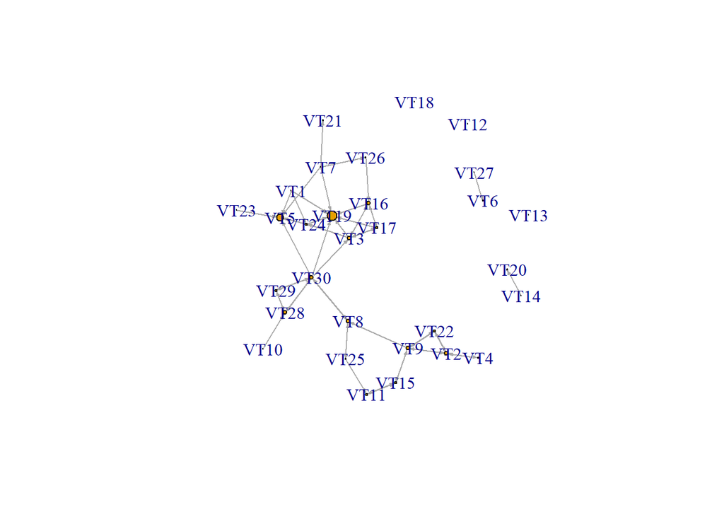

```r
outdeg.off2015 <- off2015
V(outdeg.off2015)$size <- outdegree_off2015
E(outdeg.off2015)$arrow.size <- 0.2
set.seed(1234)
plot(outdeg.off2015)
```

```r
#Closeness Centrality
closeness_off2015 <- igraph::closeness(off2015)
closeness_df_off2015 <- data.frame(nodeName = V(off2015)$name, closeness_off2015)
closeness_df_off2015 <- closeness_df_off2015[order(closeness_df_off2015$closeness_off2015, decreasing = TRUE),]
head(closeness_df_off2015, 7)
```

```
##      nodeName closeness_off2015
## VT9       VT9       0.002331002
## VT30     VT30       0.002298851
## VT8       VT8       0.002293578
## VT10     VT10       0.002293578
## VT25     VT25       0.002277904
## VT2       VT2       0.002267574
## VT15     VT15       0.002262443
```

```r
mean(closeness_df_off2015$closeness_off2015)
```

```
## [1] 0.001649575
```

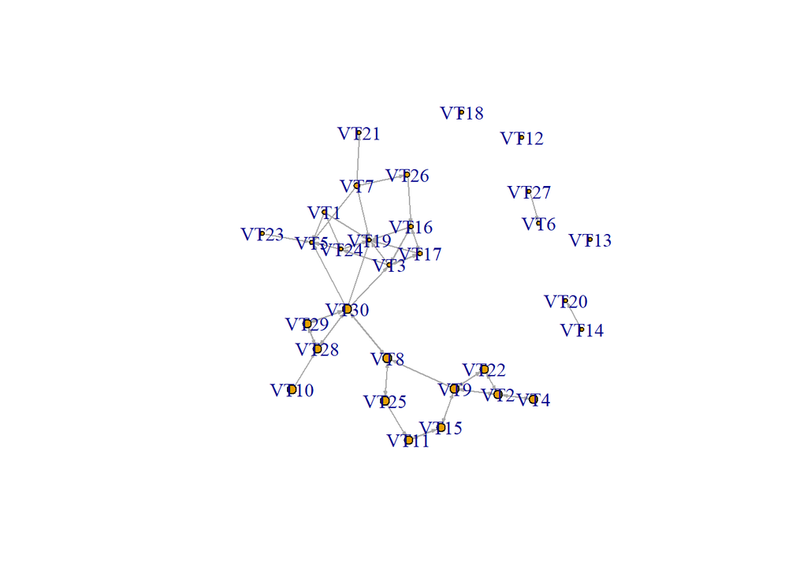

```r
clo.off2015 <- off2015
V(clo.off2015)$size <- closeness_off2015*2500
E(clo.off2015)$arrow.size <- 0.2
set.seed(1234)
plot(clo.off2015)
```

```r
#Betweenness Centrality
betweenness_off2015 <- igraph::betweenness(off2015)
betweenness_df_off2015 <- data.frame(nodeName = V(off2015)$name, betweenness_off2015)
betweenness_df_off2015 <- betweenness_df_off2015[order(betweenness_df_off2015$betweenness_off2015, decreasing = TRUE),]
head(betweenness_df_off2015, 7)
```

```
##      nodeName betweenness_off2015
## VT30     VT30                 106
## VT8       VT8                  97
## VT9       VT9                  85
## VT3       VT3                  43
## VT15     VT15                  43
## VT11     VT11                  30
## VT25     VT25                  30
```

```r
mean(betweenness_df_off2015$betweenness_off2015)
```

```
## [1] 16.36667
```

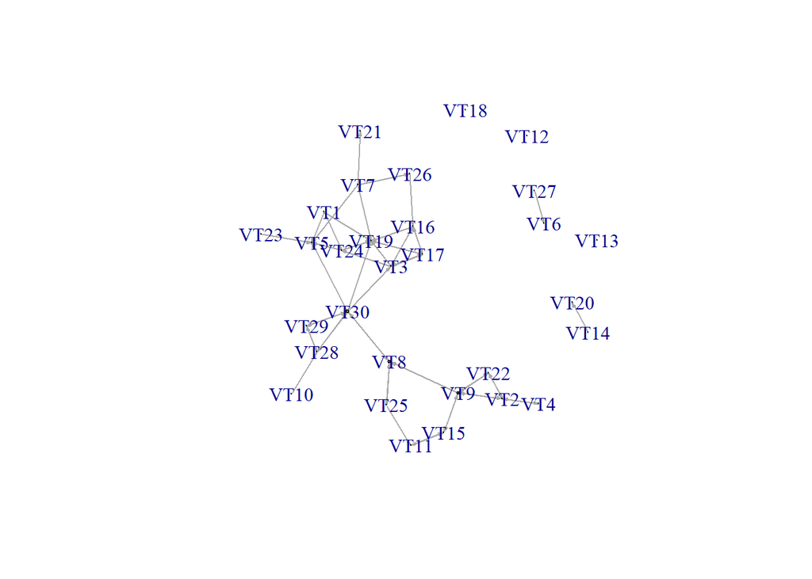

```r
bet.off2015 <- off2015
V(bet.off2015)$size <- betweenness_off2015 / 50
E(bet.off2015)$arrow.size <- 0.2
set.seed(1234)
plot(bet.off2015)
```

Centrality parameters for unpaddled ‘often -2015’:

- In-degree centrality mean:1.7
- Out-degree centrality mean: 1.7
- Closeness centrality mean: 0.00165
- Betweenness centrality mean: 16.3667

Findings:

- Since in-degree and out-degree centrality average is both at 1.7, which indicates people have rather low connections to the rest of the network members.
- Due to the disconnection in the network, the closeness centrality is somehow biased. Yet the lower average of 0.00165 still tells the close connection within the connected group members.
- While looking at the betweenness centrality plot and table, we found that VT30, VT8, and VT9 has very high betweenness, about 85 to 100 compared with mean betweenness of 16.37. Thus, we can tell those three person acts an important role of bridges to connect other network members.

```r
#In-degre Centrality
indegree_truu2015 <- igraph::degree(truu2015, mode = "in")
indegree_df_truu2015 <- data.frame(Node = V(truu2015)$name, indegree_truu2015)
indegree_df_truu2015 <- indegree_df_truu2015[order(indegree_df_truu2015$indegree_truu2015, decreasing = TRUE),]
mean(indegree_df_truu2015$indegree_truu2015)
```

```
## [1] 3.333333
```

```r
indeg.truu2015 <- truu2015
V(indeg.truu2015)$size <- indegree_truu2015
E(indeg.truu2015)$arrow.size <- 0.2
set.seed(1234)
plot(indeg.truu2015)
#Out-degree Centrality
outdegree_truu2015 <- igraph::degree(truu2015, mode = "in")
outdegree_df_truu2015 <- data.frame(nodeName = V(truu2015)$name, outdegree_truu2015)
outdegree_df_truu2015 <- outdegree_df_truu2015[order(outdegree_df_truu2015$outdegree_truu2015, decreasing = TRUE),]
mean(outdegree_df_truu2015$outdegree_truu2015)
```

```
## [1] 3.333333
```

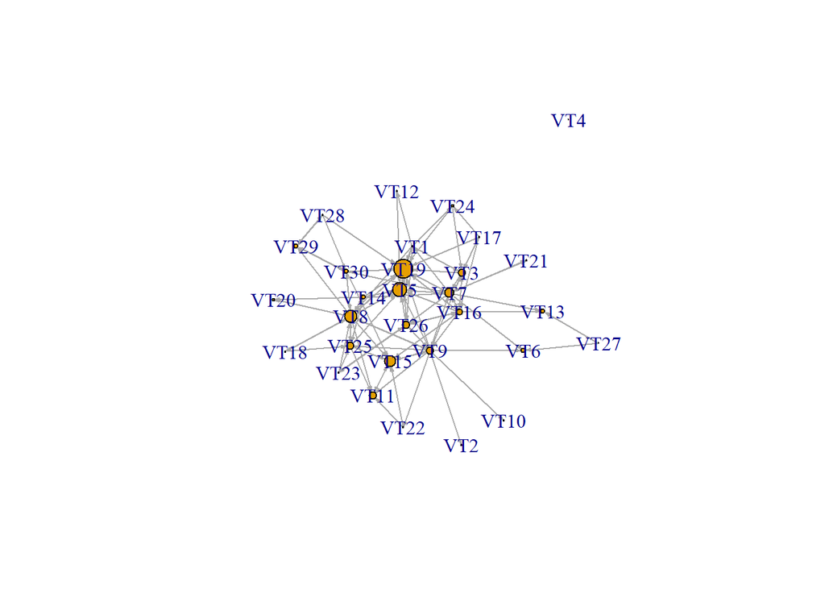

```r
outdeg.truu2015 <- truu2015
V(outdeg.truu2015)$size <- outdegree_truu2015
E(outdeg.truu2015)$arrow.size <- 0.2
set.seed(1234)
plot(outdeg.truu2015)
```

```r
#Closeness Centrality
closeness_truu2015 <- igraph::closeness(truu2015)
closeness_df_truu2015 <- data.frame(nodeName = V(truu2015)$name, closeness_truu2015)
closeness_df_truu2015 <- closeness_df_truu2015[order(closeness_df_truu2015$closeness_truu2015, decreasing = TRUE),]
head(closeness_df_truu2015, 7)
```

```
##      nodeName closeness_truu2015
## VT9       VT9        0.009615385
## VT8       VT8        0.008849558
## VT1       VT1        0.008771930
## VT16     VT16        0.008771930
## VT7       VT7        0.008695652
## VT3       VT3        0.008547009
## VT14     VT14        0.008474576
```

```r
mean(closeness_df_truu2015$closeness_truu2015)
```

```
## [1] 0.005862334
```

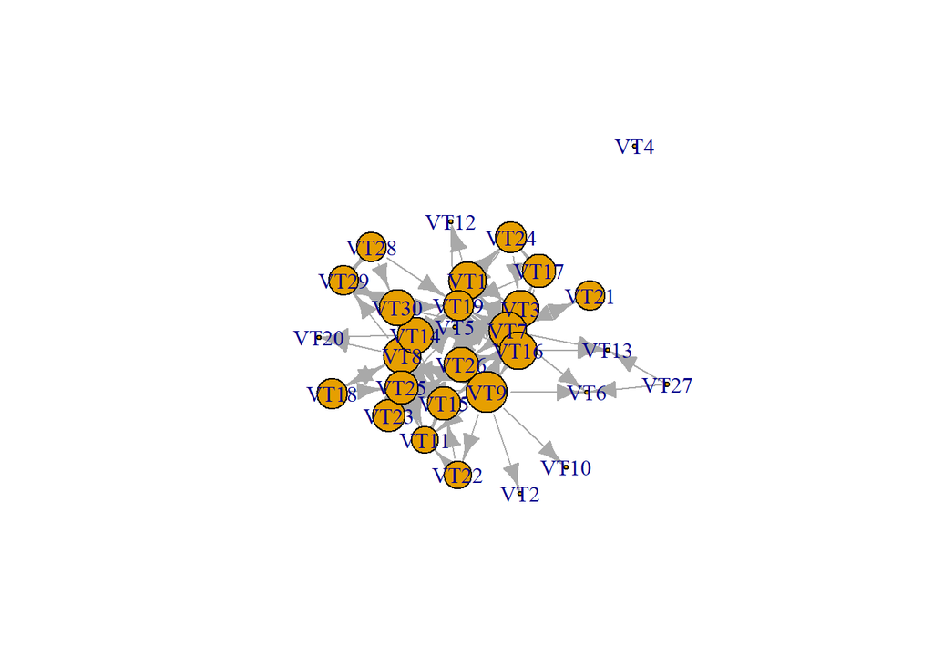

```r
clo.truu2015 <- truu2015
V(clo.truu2015)$size <- closeness_truu2015*2500
set.seed(1234)
plot(clo.truu2015)
```

```r
#Betweenness Centrality
betweenness_truu2015 <- igraph::betweenness(truu2015)
betweenness_df_truu2015 <- data.frame(nodeName = V(truu2015)$name, betweenness_truu2015)
betweenness_df_truu2015 <-betweenness_df_truu2015[order(betweenness_df_truu2015$betweenness_truu2015, decreasing = TRUE),]
head(betweenness_df_truu2015, 7)
```

```
##      nodeName betweenness_truu2015
## VT9       VT9            185.99444
## VT8       VT8            169.99683
## VT7       VT7            142.91905
## VT15     VT15             64.10238
## VT3       VT3             51.26667
## VT30     VT30             50.39444
## VT1       VT1             40.65238
```

```r
mean(betweenness_df_truu2015$betweenness_truu2015)
```

```
## [1] 28.96667
```

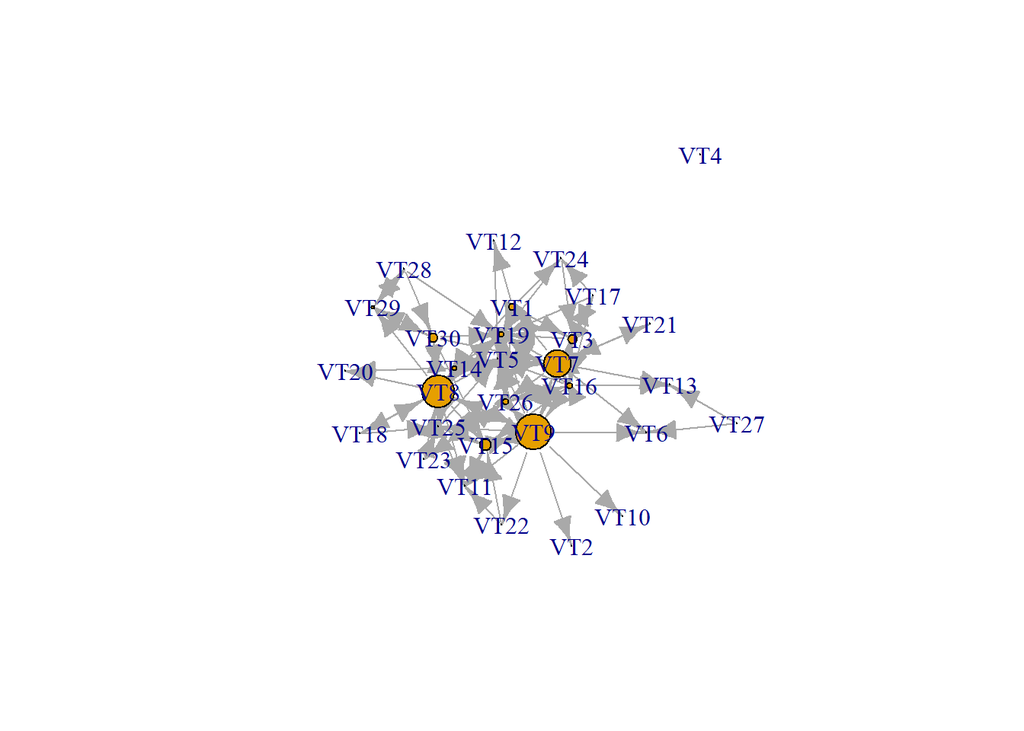

```r
bet.truu2015 <- truu2015
V(bet.truu2015)$size <- betweenness_truu2015 / 10
set.seed(1234)
plot(bet.truu2015)
```

Centrality parameters for unpaddled ‘trust -2015’:

- In-degree centrality mean:3.33
- Out-degree centrality mean: 3.33
- Closeness centrality mean: 0.00586
- Betweenness centrality mean: 28.967

Findings:

- Since in-degree and out-degree centrality average is both at 3.33, which indicates people have rather low connections to the rest of the network members.
- Due to the disconnection in the network, the closeness centrality is somehow biased. Yet the lower average of 0.00586 still tells the close connection within the connected group members.
- While looking at the betweenness centrality plot and table, we found that VT9, VT8, and VT7 has very high betweenness, about 140 to 185 compared with mean betweenness of 29. Thus, we can tell those three person acts an important role of bridges to connect other network members.
- Also, V8 and V9 are aloo important bridges in often contact network.

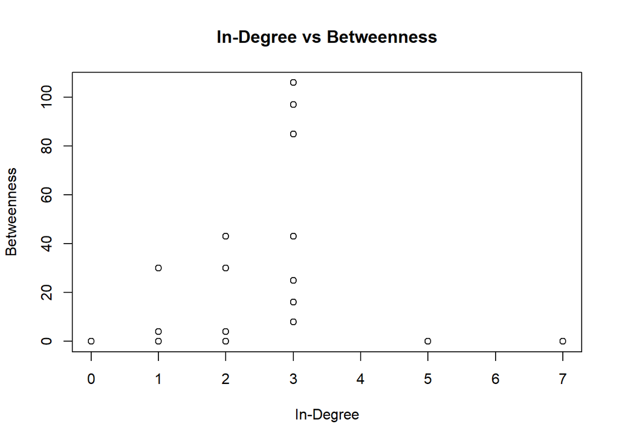

```r
# for 'often - 2015' network
# In-Degree vs Betweenness
betweenness_of2015 <- igraph::betweenness(of2015)
plot(betweenness_of2015 ~ indegree_of2015,
     main = "In-Degree vs Betweenness",
     xlab = "In-Degree", ylab = "Betweenness")
```

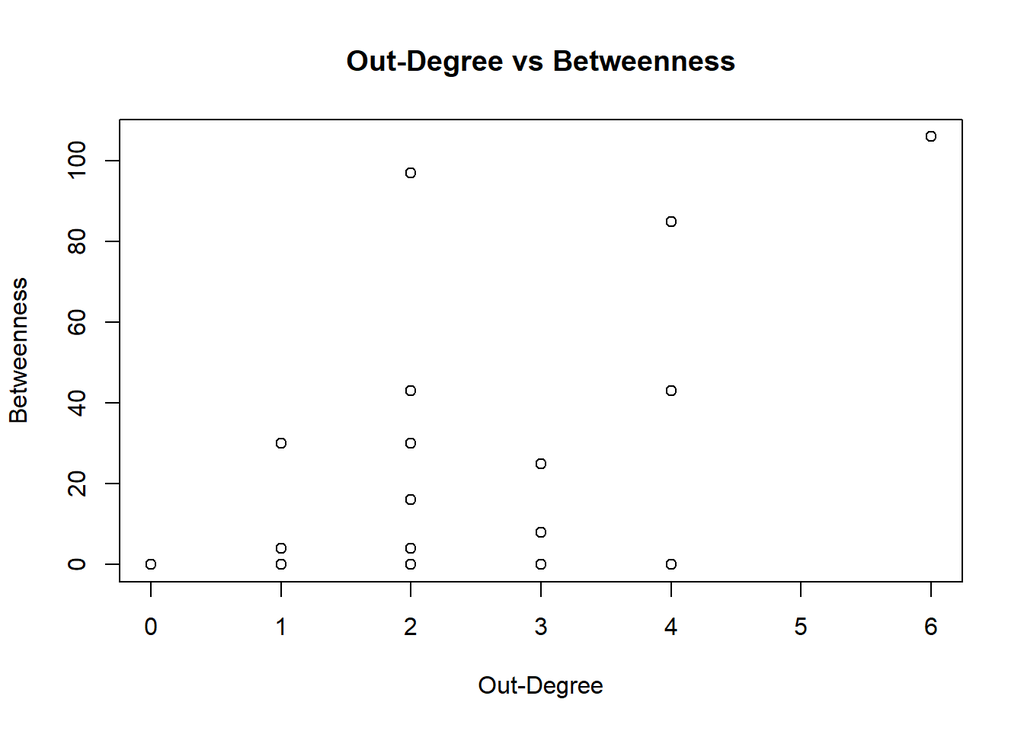

```r
#Out-Degree vs Betweenness
plot(betweenness_of2015 ~ outdegree_of2015,
     main = "Out-Degree vs Betweenness",
     xlab = "Out-Degree", ylab = "Betweenness")
```

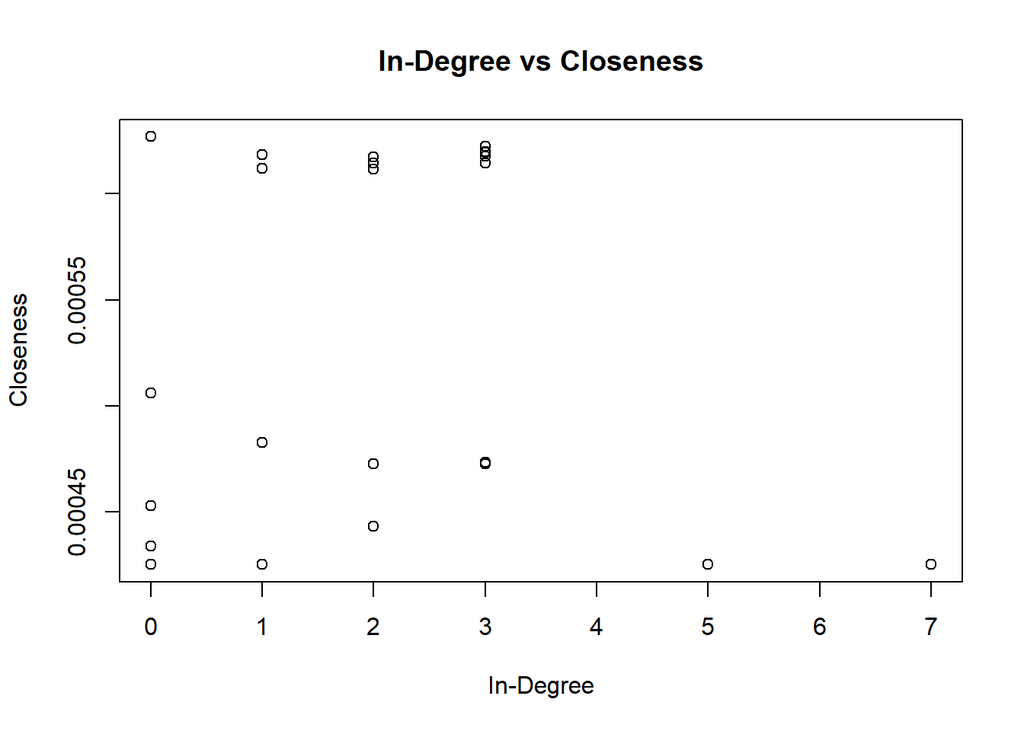

```r
#In-Degree vs. Closeness
closeness_of2015 <- igraph::closeness(of2015)
plot(closeness_of2015 ~ indegree_of2015,
     main = "In-Degree vs Closeness",
     xlab = "In-Degree", ylab = "Closeness")
```

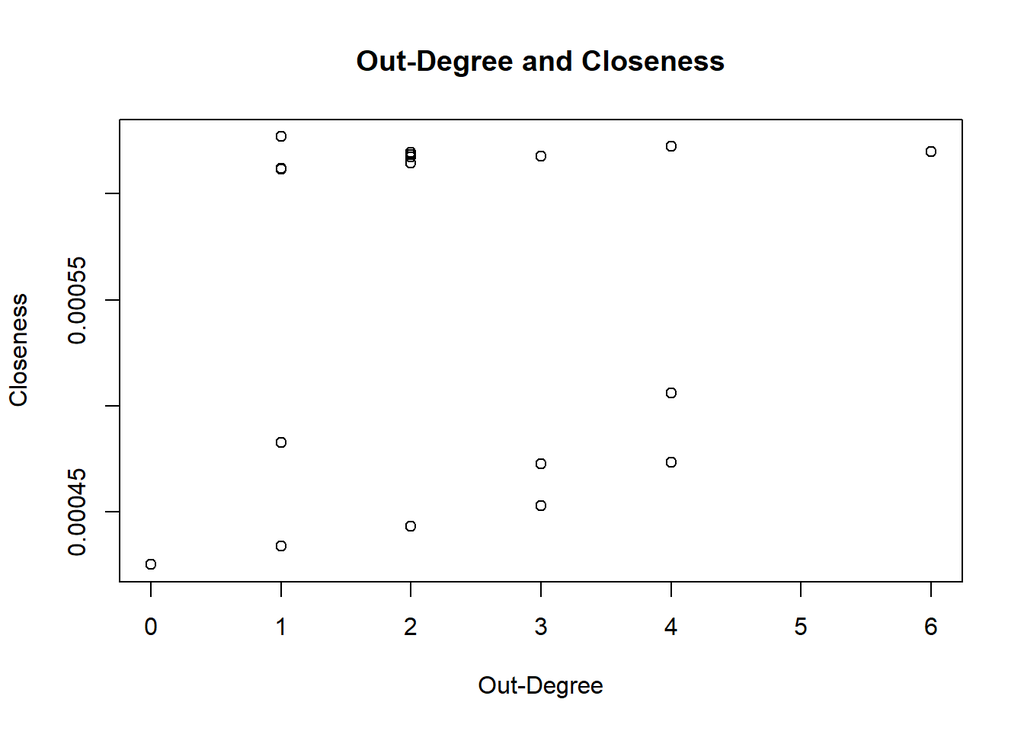

```r
#Out-Degree vs Closeness
plot(closeness_of2015 ~ outdegree_of2015,
     main = "Out-Degree and Closeness",
     xlab = "Out-Degree", ylab = "Closeness")
```

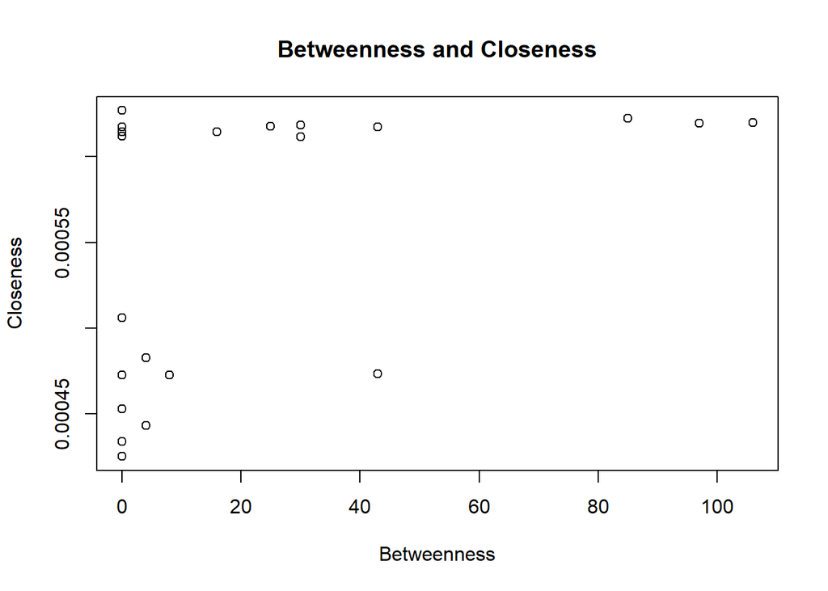

```r
#Betweenness vs Closeness
plot(closeness_of2015 ~ betweenness_of2015,
     main = "Betweenness and Closeness",
     xlab = "Betweenness", ylab = "Closeness")
```

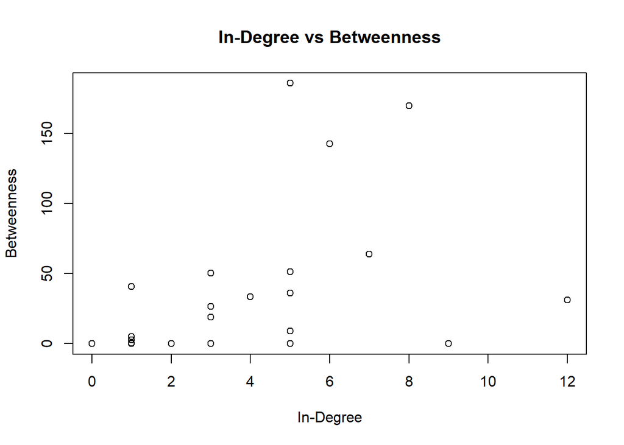

```r
# for 'trust - 2015' network
# In-Degree vs Betweenness
betweenness_tru2015 <- igraph::betweenness(tru2015)
plot(betweenness_tru2015 ~ indegree_tru2015,
     main = "In-Degree vs Betweenness",
     xlab = "In-Degree", ylab = "Betweenness")
```

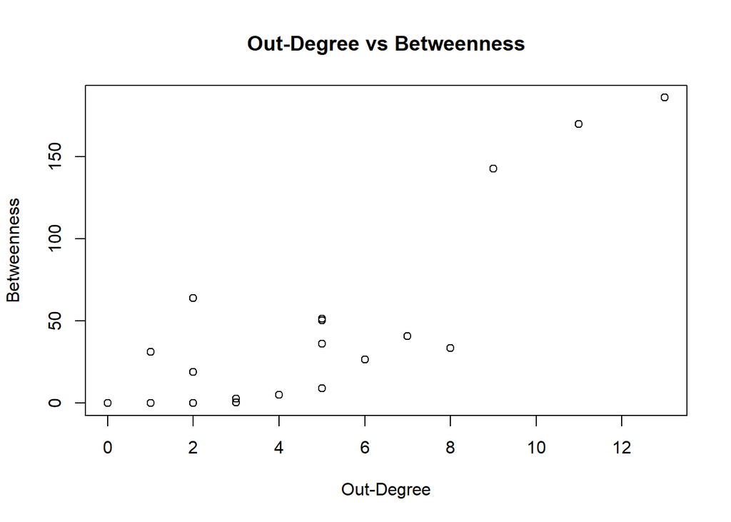

```r
#Out-Degree vs Betweenness
plot(betweenness_tru2015 ~ outdegree_tru2015,
     main = "Out-Degree vs Betweenness",
     xlab = "Out-Degree", ylab = "Betweenness")
```